[OHI British Columbia](http://www.ohibc.org/) | [OHI Science](http://ohi-science.org) | [Citation policy](https://github.com/OHI-Science/ohiprep/releases)

# OHIBC: data_prep_ico.Rmd

Compiled on Tue Dec 1 15:22:04 2015 by ohara

# 1 OHIBC Iconic Species Subgoal (Sense of Place)

This script prepares scores (status and trend) for Iconic Species in British Columbia’s coastal regions. Spatial data from IUCN and Aquamaps is combined with extinction risk information from IUCN and conservation rank info based on NatureServe categories.

Currently, the Iconic Species sub-goal model is identical to the OHI Global model: a region’s status is based upon an unweighted average of species health for all ‘iconic’ species found within each BC reporting region.

From Halpern et al (2012):

> Iconic species are those that are relevant to local cultural identity through a species’ relationship to one or more of the following: 1) traditional activities such as fishing, hunting or commerce; 2) local ethnic or religious practices; 3) existence value; and 4) locally-recognized aesthetic value (e.g., touristic attractions/common subjects for art such as whales). Habitat-forming species are not included in this definition of iconic species, nor are species that are harvested solely for economic or utilitarian purposes (even though they may be iconic to a sector or individual). …

> Ultimately, almost any species can be iconic to someone, and so the intent with this goal was to focus on those species widely seen as iconic within a country, and iconic from a cultural or existence value (rather than for a livelihoods or extractive reason). …

> The reference point is to have the risk status of all assessed species as Least Concern (i.e., a goal score = 1.0)

The Status of this sub-goal (X<sub>ICO</sub>) is then the % of iconic species in each threat category (as defined by the IUCN Red List, and for OHIBC, NatureServe), such that:

$X_{ICO} = \frac{\displaystyle\sum_{category}S_{cat}*w_{cat}}{\displaystyle\sum_{category}S_{cat}}$

where for each IUCN threat category (or analogous NatureServe conservation rank):

- *S<sub>cat</sub>* is the number of assessed species in the category
- *w<sub>cat</sub>* is the status weight assigned for that category (note, these are the inverse of the risk value used in the SPP calculations):
  - ‘LC’ = 1.0, ‘NT’ = 0.8, ‘VU’ = 0.6, ‘EN’ = 0.4, ‘CR’ = 0.2, ‘EX’ = 0.0
  - NatureServe ranks are assigned analogous scores
  - Where available, NatureServe province-scale ranks take precedence over IUCN ranks as they are a better representation of the risk at the scale of British Columbia.

ICO trend is calculated in a similar manner, but weightings are assigned according to IUCN population trend: ‘Decreasing’ = -0.5, ‘Stable’ = 0.0, ‘Increasing’ = +0.5. NatureServe information on population trend was not readily available.

# 2 Data Preparation

## 2.1 Data Sources

For information on IUCN data (range maps, extinction risk categories, population trends), NatureServe (conservation rankings), and AquaMaps (range maps), please see the OHIBC SPP data prep document, since this ICO goal is calculated from the intermediate outputs of that workflow.

Iconic Species List:

- The OHI global iconic species list was created by combining three species lists from WWF Global: global priorities, regional and local priorities, and flagship species

## 2.2 Prepare master list of Iconic Species

Get list of all species listed as “iconic” for BC. For now, the analysis is based on the global list of Iconic Species, filtered to just the species that occur in BC.

To this global ICO species list, we attach `spp_all_bcsee` df to acquire IUCN category & trend, and NatureServe global and provincial conservation rank information.

## 2.3 Find BC-specific cell locations for all species on ICO list

Using same raster method as for SPP, identify .5 deg cells within BC regions. Then filter IUCN and AM lists to just species on ico_list, and just cells within BC regions.

At this point we have 3413 species/cell instances based on IUCN spatial data, and 6682 species/cell instances based on AM spatial data.

**NOTE:** Unlike the SPP goal, in which IUCN data was preferentially used to identify cell locations for a species, for ICO I am allowing both IUCN and Aquamaps datasets to indicate presence of an iconic species in a given cell.

For example, if in cell #65000, for Tursiops truncatus, IUCN indicates presence and Aquamaps does not, it will be registered as present. But if in cell #65001, Aquamaps indicates presence and IUCN does not, it will also by registered as present (whereas in SPP it would register as NOT present).

Because the spatially explicit range is not critical, but rather just whether the species is present or absent within a give assessment region, it seems reasonable to consider both spatial sources.

Iconic Species currently identified within British Columbia waters: *Balaenoptera acutorostrata, Balaenoptera borealis, Balaenoptera musculus, Balaenoptera physalus, Megaptera novaeangliae, Grampus griseus, Eschrichtius robustus, Physeter macrocephalus, Ziphius cavirostris, Delphinus delphis, Stenella coeruleoalba, Eubalaena japonica, Tursiops truncatus, Isurus oxyrinchus, Alopias vulpinus, Prionace glauca, Galeocerdo cuvier, Cetorhinus maximus, Caretta caretta, Dermochelys coriacea, Isurus paucus, Carcharodon carcharias*.

### 2.3.1 Map of species count by cell

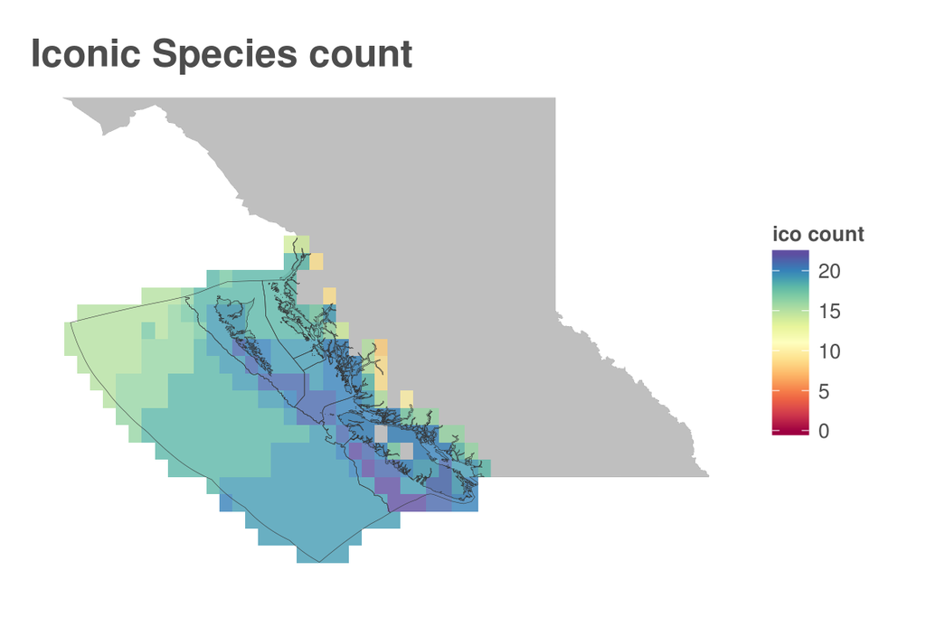

# 3 Calculate Goal Model

## 3.1 Summarize mean category/trend per cell/region, IUCN

For each raster cell, we generate a summary of number of species included, average extinction risk score of all species in cell, and average trend score of all species in cell with population trend information. This section calculates extinction risk score based solely on IUCN category ranks, which excludes subpopulation scores due to lack of spatially explicit distribution info for subpopulations.

From raster-level summaries, we generate a region-level summary based on area-weighted average extinction risk and population trend.

| rgn_id | rgn_name | sciname | category_score | trend_score |
| --- | --- | --- | --- | --- |
| 1 | North Coast | Balaenoptera acutorostrata | 0.2 | 0 |
| 1 | North Coast | Balaenoptera borealis | 1 |  |
| 1 | North Coast | Balaenoptera musculus | 0.8 | 0.5 |
| 1 | North Coast | Balaenoptera physalus | 0.6 |  |
| 1 | North Coast | Megaptera novaeangliae | 0.4 | 0.5 |
| 1 | North Coast | Grampus griseus | 0.2 |  |
| 1 | North Coast | Eschrichtius robustus | 0.4 | 0 |
| 1 | North Coast | Physeter macrocephalus | 0.3 |  |
| 1 | North Coast | Ziphius cavirostris | 0 |  |
| 1 | North Coast | Eubalaena japonica | 1 |  |

[output cut: 159 more lines]

| rgn_id | rgn_name | n_ico | mean_cat | mean_trend |
| --- | --- | --- | --- | --- |
| 1 | North Coast | 20 | 0.41 | -0.166666666666667 |
| 2 | Haida Gwaii | 21 | 0.39047619047619 | -0.166666666666667 |
| 3 | Central Coast | 21 | 0.39047619047619 | -0.166666666666667 |
| 4 | North Vancouver Island | 22 | 0.390909090909091 | -0.166666666666667 |
| 5 | West Vancouver Island | 22 | 0.390909090909091 | -0.166666666666667 |
| 6 | Strait of Georgia | 21 | 0.39047619047619 | -0.166666666666667 |
| 7 | Pacific Offshore | 22 | 0.390909090909091 | -0.166666666666667 |
| 8 | Aristazabal Island | 20 | 0.41 | -0.166666666666667 |

### 3.1.1 Map of mean extinction risk category and population trend by cell

*Category value range: least concern = 0, extinct = 1*

*Trend value range: population increasing = +0.5, stable = 0, decreasing = -0.5*

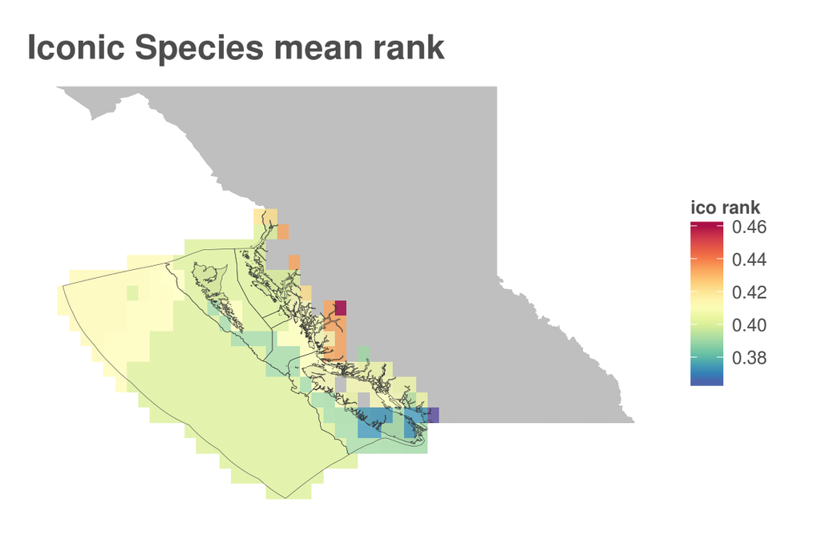

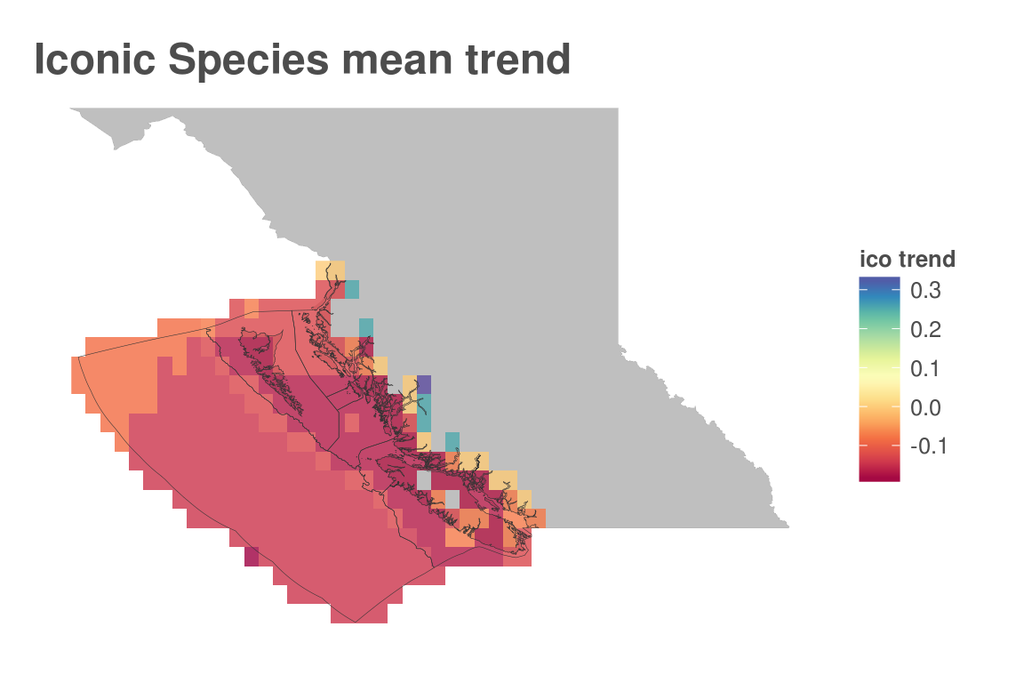

## 3.2 Create final output files

From the region-level summaries of extinction risk and population trend, we calculate regional status and trend scores, and save as .csv.

Writing ICO status and trend to: ~/github/ohibc/prep/spp_ico/v2016/data/ico_status.csv ~/github/ohibc/prep/spp_ico/v2016/data/ico_trend.csv

## 3.3 Compare status and trend by region

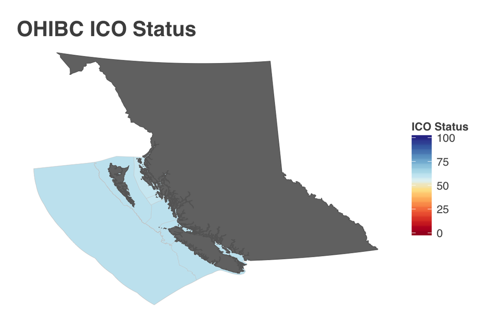

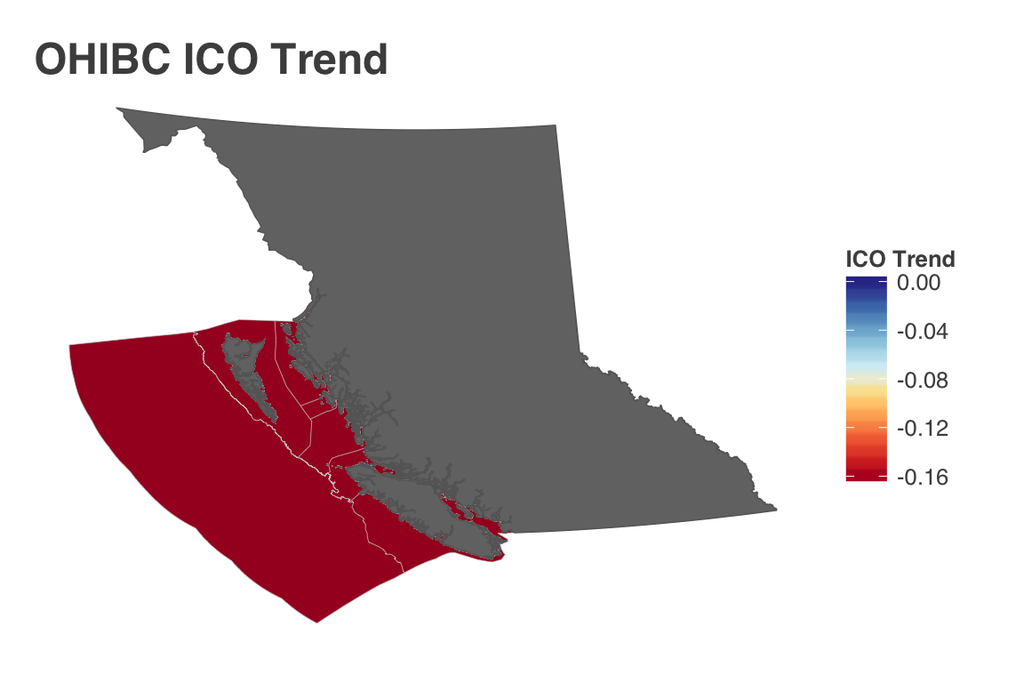

| rgn_id | rgn_name | status | trend |
| --- | --- | --- | --- |
| 1 | North Coast | 59 | -0.167 |
| 2 | Haida Gwaii | 60.95 | -0.167 |
| 3 | Central Coast | 60.95 | -0.167 |
| 4 | North Vancouver Island | 60.91 | -0.167 |
| 5 | West Vancouver Island | 60.91 | -0.167 |
| 6 | Strait of Georgia | 60.95 | -0.167 |
| 7 | Pacific Offshore | 60.91 | -0.167 |
| 8 | Aristazabal Island | 59 | -0.167 |

# 4 Provenance

- *Run ID: 2; run tag: “standard run”*
- *System info: System: Darwin, Release: 15.0.0. Machine: x86_64. User: ohara.*
- *Session info*
  - *R version: R version 3.2.2 (2015-08-14), Platform: x86_64-apple-darwin13.4.0, Running under: OS X 10.11.1 (El Capitan).*
  - *Attached base packages: stats, graphics, grDevices, utils, datasets, methods, base*
  - *Other attached packages: maptools_0.8-36, RColorBrewer_1.1-2, ggplot2_1.0.1, readr_0.1.1, stringr_1.0.0, tidyr_0.3.1, dplyr_0.4.3, data.table_1.9.6, raster_2.4-20, rgdal_1.0-4, sp_1.2-0*

Provenance summary for this run:

| run_id | run_tag | run_date | file_loc | type | commit_url | commit_author | commit_date | uncommitted_changes |
| --- | --- | --- | --- | --- | --- | --- | --- | --- |
| 2 | standard run | Tue Dec 1 15:31:53 2015 | ~/github/ohibc/prep/spp_ico/R/spp_fxn.R | sourced script | https://github.com/OHI-Science/ohibc/commit/3a54d7bd19f038b605f2f9d66dd88c27043c980d | Casey O’Hara ohara@nceas.ucsb.edu | Tue Nov 17 18:59:50 2015 -0800 | FALSE |
| 2 | standard run | Tue Dec 1 15:31:53 2015 | ~/github/ohibc/prep/spp_ico/v2016/ico_list_ohibc.csv | input | https://github.com/OHI-Science/ohibc/commit/b014927db4445d63bc01ddf683252c301cd59d0f | Casey O’Hara ohara@nceas.ucsb.edu | Wed Oct 28 11:55:33 2015 -0700 | FALSE |
| 2 | standard run | Tue Dec 1 15:31:53 2015 | ~/github/ohibc/prep/spp_ico/v2016/int/spp_all_bcsee.csv | input | https://github.com/OHI-Science/ohibc/commit/b014927db4445d63bc01ddf683252c301cd59d0f | Casey O’Hara ohara@nceas.ucsb.edu | Wed Oct 28 11:55:33 2015 -0700 | FALSE |
| 2 | standard run | Tue Dec 1 15:31:53 2015 | ~/github/ohibc/prep/regions/ohibc_rgn_wgs84.shp | input | https://github.com/OHI-Science/ohibc/commit/b014927db4445d63bc01ddf683252c301cd59d0f | Casey O’Hara ohara@nceas.ucsb.edu | Wed Oct 28 11:55:33 2015 -0700 | FALSE |
| 2 | standard run | Tue Dec 1 15:31:53 2015 | ~/github/ohibc/prep/spp_ico/v2016/int/cell_id_by_rgn.csv | input | https://github.com/OHI-Science/ohibc/commit/b014927db4445d63bc01ddf683252c301cd59d0f | Casey O’Hara ohara@nceas.ucsb.edu | Wed Oct 28 11:55:33 2015 -0700 | FALSE |
| 2 | standard run | Tue Dec 1 15:31:53 2015 | ~/github/ohibc/prep/spp_ico/v2016/int/am_cells_spp_prob0.csv | input | https://github.com/OHI-Science/ohibc/commit/b014927db4445d63bc01ddf683252c301cd59d0f | Casey O’Hara ohara@nceas.ucsb.edu | Wed Oct 28 11:55:33 2015 -0700 | FALSE |
| 2 | standard run | Tue Dec 1 15:31:53 2015 | ~/github/ohibc/prep/spp_ico/v2016/data/ico_status.csv | output | Previous commit: https://github.com/OHI-Science/ohibc/commit/b014927db4445d63bc01ddf683252c301cd59d0f | Casey O’Hara ohara@nceas.ucsb.edu | Wed Oct 28 11:55:33 2015 -0700 | FALSE |
| 2 | standard run | Tue Dec 1 15:31:53 2015 | ~/github/ohibc/prep/spp_ico/v2016/data/ico_trend.csv | output | Previous commit: https://github.com/OHI-Science/ohibc/commit/b014927db4445d63bc01ddf683252c301cd59d0f | Casey O’Hara ohara@nceas.ucsb.edu | Wed Oct 28 11:55:33 2015 -0700 | FALSE |
| 2 | standard run | Tue Dec 1 15:31:53 2015 | ~/github/ohibc/prep/spp_ico/data_prep_ico.Rmd | script | https://github.com/OHI-Science/ohibc/commit/ac06d7754a233ea63b9efe14f8bbb44d2a48a12e | Casey O’Hara ohara@nceas.ucsb.edu | Wed Nov 18 10:05:31 2015 -0800 | TRUE |